# Lab 3 Individual Analysis

Isaac Tegeler

9/22/2020

load data:

```r
library(readxl)
```

```r
library(ggplot2)
library(dplyr)
data <- readxl::read_xls('GSS.xls')
colnames(data)[9] <- "Education"
colnames(data)[6] <- "Party"
colnames(data)[4] <- "Enviroment"
colnames(data)[1] <- "Year"
data$`Education` <- as.numeric(data$Education)
```

## Part 2

**1.** Find the average years of education for the respondents with each political party affiliation. Arrange your output in a meaningful order and print. Describe any patterns you find.

```r
data %>%
  group_by(`Party`) %>%
  na.omit() %>%
  summarise(mean = mean(Education, na.rm = TRUE)) %>%
  arrange(mean)
```

```
## # A tibble: 10 x 2
##    Party               mean
##    <chr>              <dbl>
##  1 Don't know          10.9
##  2 No answer           12.3
##  3 Independent         12.3
##  4 Strong democrat     12.5
##  5 Not str democrat    12.6
##  6 Ind,near dem        13.2
##  7 Not str republican  13.3
##  8 Ind,near rep        13.3
##  9 Other party         13.4
## 10 Strong republican   13.4
```

The data shows that on average those who are independent / don’t know what party have the lowest number of years in school, democrats have the second shortest number of years, and republicans the most. Those that are from smaller 3rd parties have the second most years of education.

**2.** Create a single data frame containing records for the better educated respondents in each political party affiliation. A “better educated” respondent is someone who has strictly more years of education than the median in the same party affiliation. Print the structure of the data frame.

```r
best_ed <- data %>%
  group_by(Party) %>%
  filter(Education >= median(Education, na.rm = TRUE)) %>%
  ungroup()

str(best_ed)
```

```
## tibble [40,925 x 12] (S3: tbl_df/tbl/data.frame)
##  $ Year                          : num [1:40925] 1972 1972 1972 1972 1972 ...
##  $ General happiness             : chr [1:40925] "Not too happy" "Pretty happy" "Not too happy" "Pretty happy" ...
##  $ Solving problems of big cities: chr [1:40925] "Not applicable" "Not applicable" "Not applicable" "Not applicable" ...
##  $ Enviroment                    : chr [1:40925] "Not applicable" "Not applicable" "Not applicable" "Not applicable" ...
##  $ Space exploration program     : chr [1:40925] "Not applicable" "Not applicable" "Not applicable" "Not applicable" ...
##  $ Party                         : chr [1:40925] "Ind,near dem" "Independent" "Not str democrat" "Strong democrat" ...
##  $ Region of interview           : chr [1:40925] "E. nor. central" "E. nor. central" "E. nor. central" "E. nor. central" ...
##  $ Respondents sex               : chr [1:40925] "Female" "Female" "Female" "Female" ...
##  $ Education                     : num [1:40925] 16 12 17 12 14 13 16 12 12 13 ...
##  $ Marital status                : chr [1:40925] "Never married" "Married" "Married" "Married" ...
##  $ Respondent id number          : num [1:40925] 1 3 4 5 6 7 8 9 10 11 ...
##  $ Ballot used for interview     : chr [1:40925] "Not applicable" "Not applicable" "Not applicable" "Not applicable" ...
```

3. How is the happiness of a respondent related to his/her marriage status? Define that a person is happy if the response to question is “Very happy” or “Pretty happy”.

```r
happy_tr <- function(arg_1){
  ifelse(arg_1 == "Pretty happy" | arg_1 == "Very happy", "Happy", "Unhappy")
}
happy <- data %>%
  na.omit %>%
  mutate(Happiness = happy_tr(`General happiness`)) %>%
  group_by(`Marital status`, Happiness) %>%
  summarise(count = n()) %>%
  mutate(total = sum(count)) %>%
  ungroup()
```

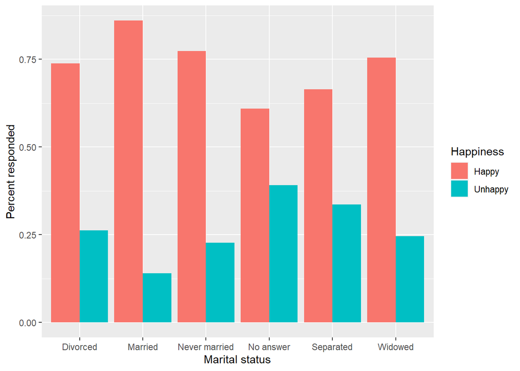

```r
ggplot(happy, aes(x=`Marital status`,y=count/total, fill=Happiness)) + geom_bar(stat="identity", position=position_dodge()) + ylab("Percent responded")
```

```r
happy
```

```
## # A tibble: 12 x 4
##    `Marital status` Happiness count total
##    <chr>            <chr>     <int> <int>
##  1 Divorced         Happy      6169  8363
##  2 Divorced         Unhappy    2194  8363
##  3 Married          Happy     29285 34053
##  4 Married          Unhappy    4768 34053
##  5 Never married    Happy     10665 13801
##  6 Never married    Unhappy    3136 13801
##  7 No answer        Happy        14    23
##  8 No answer        Unhappy       9    23
##  9 Separated        Happy      1482  2233
## 10 Separated        Unhappy     751  2233
## 11 Widowed          Happy      4649  6164
## 12 Widowed          Unhappy    1515  6164
```

In the plot above the data has been noramalized for comparison. We can see that the marital status that is the happiest are those that are married, and the most unhappy are those that are seperated/didn’t answer. One could draw the conclusion that being married has the chance to make you happier, but if it ends poorly where your spouse dies or you divorce you will be cursed to be less happy for the rest of your life. It is not garunteed as generally most people are happy with their life.

4. Does party affiliation affect the relationship you found in the last question?

```r
happy_tr <- function(arg_1){
  ifelse(arg_1 == "Pretty happy" | arg_1 == "Very happy", "Happy", "Unhappy")
}
happy <- data %>%
  na.omit %>%
  mutate(Happiness = happy_tr(`General happiness`)) %>%
  group_by(Party, `Marital status`, Happiness) %>%
  filter(Party != "Don't know") %>%
  filter(`Marital status` != "No answer") %>%
  summarise(count = n()) %>%
  mutate(total = sum(count)) %>%
  mutate(perecent = count/total) %>%
  ungroup()
```

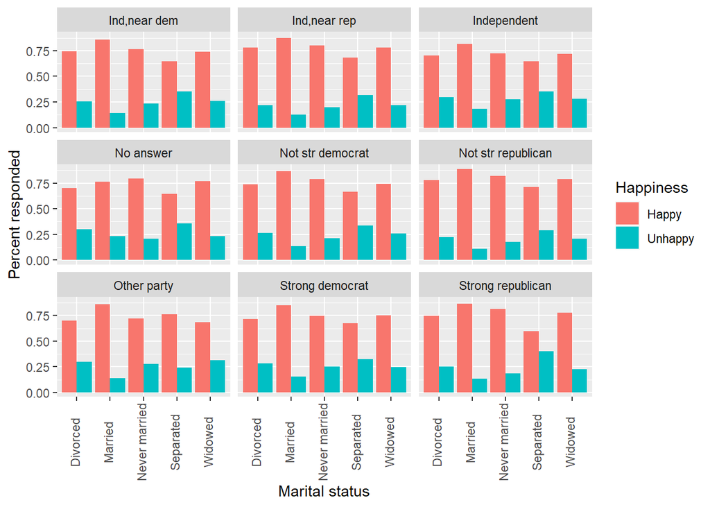

```r
ggplot(happy, aes(x=`Marital status`,y=count/total, fill=Happiness)) + geom_bar(stat="identity", position=position_dodge()) + ylab("Percent responded") + theme(axis.text.x=element_text(angle=90,vjust=0.25, hjust=.5)) + facet_wrap(~Party)
```

```r
happy
```

```
## # A tibble: 90 x 6
##    Party        `Marital status` Happiness count total perecent
##    <chr>        <chr>            <chr>     <int> <int>    <dbl>
##  1 Ind,near dem Divorced         Happy       802  1079    0.743
##  2 Ind,near dem Divorced         Unhappy     277  1079    0.257
##  3 Ind,near dem Married          Happy      3196  3717    0.860
##  4 Ind,near dem Married          Unhappy     521  3717    0.140
##  5 Ind,near dem Never married    Happy      1669  2174    0.768
##  6 Ind,near dem Never married    Unhappy     505  2174    0.232
##  7 Ind,near dem Separated        Happy       193   298    0.648
##  8 Ind,near dem Separated        Unhappy     105   298    0.352
##  9 Ind,near dem Widowed          Happy       377   509    0.741
## 10 Ind,near dem Widowed          Unhappy     132   509    0.259
## # ... with 80 more rows
```

5. How is marital status related to the education of a respondent? What are possible reasons accounting for the patterns you see?

```r
m_ed <- data %>%
  na.omit %>%
  group_by(`Marital status`) %>%
  filter(`Marital status` != "No answer") %>%
  summarise(average_ed=mean(Education))
```

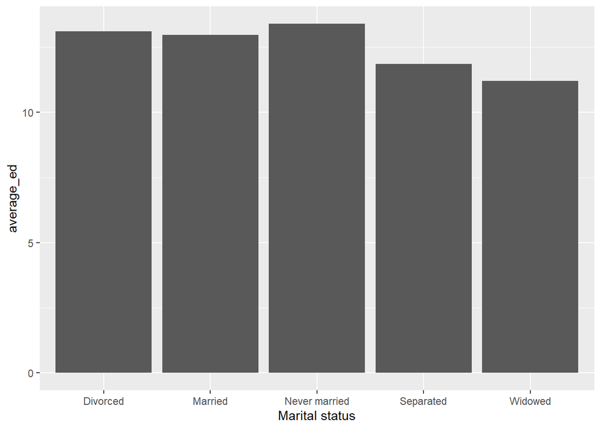

```r
ggplot(m_ed, aes(x=`Marital status`, y=average_ed)) +geom_bar(stat="identity")
```

On average those that are never married are the most educated, and those that are widowed are the least educated. One cause of this trend could be that those who are the most educated spend all of their time doing school, or research and as a result never had time to get into a relationship and get married. Those that are widowed could be older and did not need as many years of education growing up. As a result they have on average fewer years of education.

6. Explore two more interesting questions, and answer those questions using the GSS data.

q1: Is there a party divide on how much we are doing for the environment? q2: Has that changed over time?

```r
envirom <- data %>%
  filter(Enviroment != "Not applicable" & Enviroment != "No answer") %>%
  filter(Party != "Don't know" & Party != "No answer") %>%
  group_by(Party, Enviroment) %>%
  summarise(count = n()) %>%
  mutate(total = sum(count)) %>%
  ungroup()
```

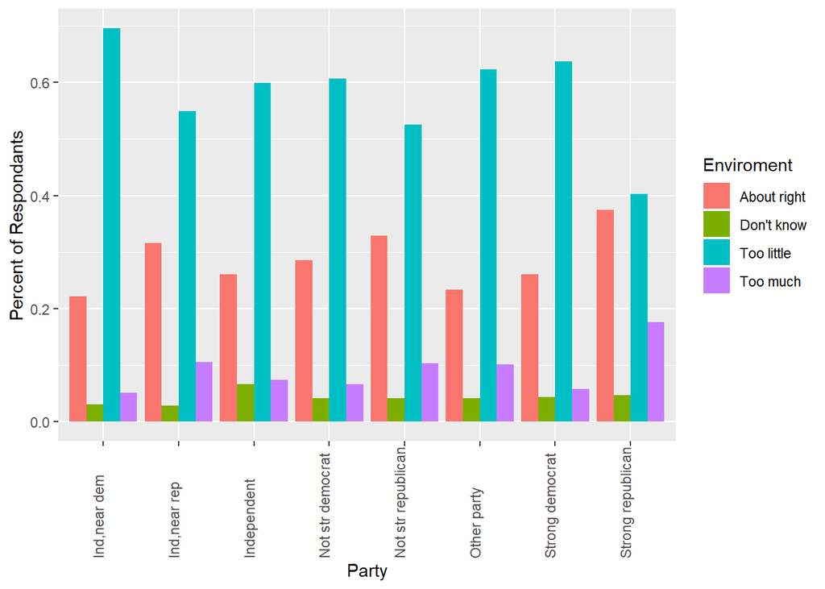

```r
ggplot(envirom, aes(x=Party, y=count/total, fill=Enviroment)) + geom_bar(stat="identity", position=position_dodge()) + theme(axis.text.x=element_text(angle=90,vjust=0, hjust=0)) + ylab("Percent of Respondants")
```

```r
envirom <- data %>%
  filter(Enviroment != "Not applicable" & Enviroment != "No answer") %>%
  filter(Party != "Don't know" & Party != "No answer") %>%
  group_by(Year, Party, Enviroment) %>%
  summarise(count = n()) %>%
  mutate(total = sum(count)) %>%
  ungroup()
```

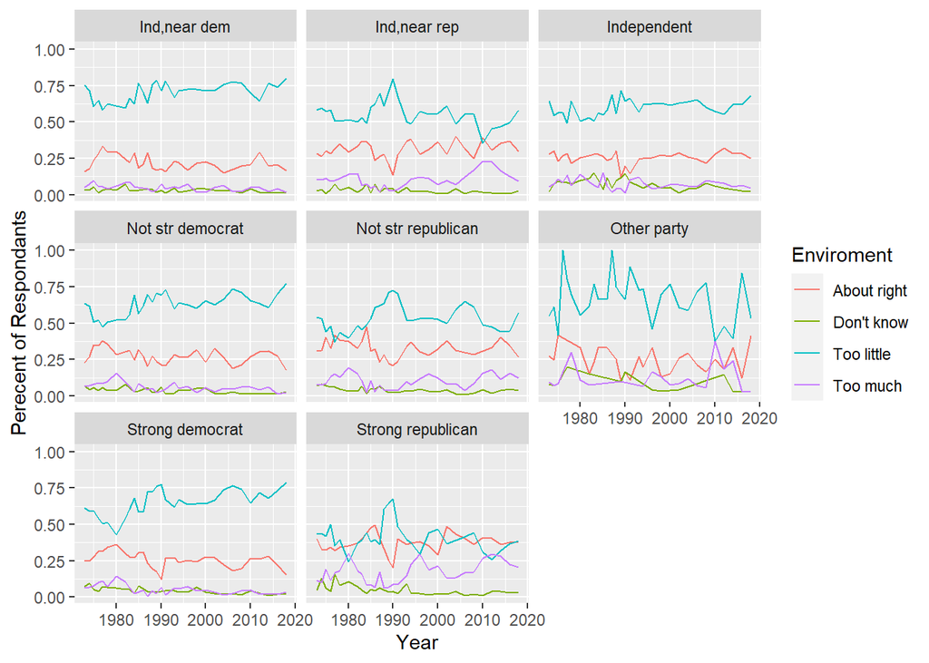

```r
ggplot(envirom, aes(x=Year, y=count/total, col=Enviroment)) + geom_line() + facet_wrap(~Party) + ylab("Perecent of Respondants")
```

It appears that there was a large spike in concern about the environment in the 90s and recently it has also begun to go back up even for strong republicans. The only party that has not seen an increase lately is those that report as other. This is likly due to the lack of data for other party wich results in a difference in trend between all other parties.